# IS580 - Term Project

Ahmet Kuzubasli (1674431), Emre Dogan (2093656), Tayfun Eylen (1626183)

6/2/2018

### Load Required Packages

First, we load all of required packages in this project at once. This allowed the project partners to load and work on the same versions of the packages.

## 1. Dataset and Introduction

We have choosen ECC dataset because it is about healthcare in what we are more professionally interested.

**Objective:** Early childhood caries (ECC) is a potentially severe disease affecting children all over the world [1]. The available ï¬ndings are mostly based on a logistic regressionmodel, but data mining could be used to extract moreinformation from the same data set. In the paper, authors implement association rule mining for interpretability. While interpretability of the model is important, we seek other methods for classification and clustering with better performance.

Secondly, we import the training, test and validation splits of ECC datasets.

## 2. Descriptrive Statistics

```r
#READ DATA
TRAIN = read.csv("./ECC_train.csv")
VALIDATION = read.csv("./ECC_validation.csv")
TEST = read.csv("./ECC_test.csv")
```

```r
## 3. Classification Methods
options(knitr.kable.NA = '')
#summary of the dataset gives us the brief information.
kable(summary(TRAIN))
```

|  | CITY | CHILD_ETHNICITY | CHILD_AGE | CHILD_GENDER | CHILD_SERBIAN_LANGUAGE | MOTHER_AGE | MARITAL_STATUS | MOTHER_ETHNICITY | MOTHER_SERBIAN_LANGUAGE | NUMBER_OF_CHILDREN | BIRTH_ORDER | MOTHER_EDUCATION_LEVEL | MOTHER_EMPLOYMENT_STATUS | QUALITY_OF_HOUSING | HOUSING_CONDITIONS | HOUSEHOLD_MONTHLY_INCOME | BIRTH_WEIGHT | BREASTFEEDING | BREASTFEEDING_FREQUENCY | BREASTFEEDING_DURING_NIGHT | BOTTLE_FEEDING | INFANT_FORMULAS | ADDITIONAL_FOOD_SWEETENING | CHILD_FLUORIDE_SUPPLEMENTS | CHILD_FLUORIDE_TOOTHPASTE | CHILD_ORAL_HYGIENE | CHILD_TOOTH_BRUSHING | DIARRHEA_DURING_INFANCY | MEDICAL_SYRUPS | … |
| --- | --- | --- | --- | --- | --- | --- | --- | --- | --- | --- | --- | --- | --- | --- | --- | --- | --- | --- | --- | --- | --- | --- | --- | --- | --- | --- | --- | --- | --- | --- |
|  | NOVI_SAD :79 | Min. :1.000 | Min. :1.00 | Min. :1.000 | Min. :1.000 | Min. :1.000 | Min. :1.000 | Min. : 1.00 | Min. :1.000 | Min. :1.0 | Min. :1.000 | Min. :1.000 | Min. :1.000 | Min. :1.000 | Min. :1.0 | Min. :1.000 | Min. :1.000 | Min. :1 | Min. : 1 | Min. : 1.00 | Min. :1.000 | Min. :1.000 | Min. :1.000 | Min. :1.000 | Min. :1.000 | Min. :1.000 | Min. :1.000 | Min. :1.0 | Min. :1.000 | … |
|  | BACKA_PALANKA:42 | 1st Qu.:1.000 | 1st Qu.:3.00 | 1st Qu.:1.000 | 1st Qu.:1.000 | 1st Qu.:2.000 | 1st Qu.:1.000 | 1st Qu.: 1.00 | 1st Qu.:1.000 | 1st Qu.:1.0 | 1st Qu.:1.000 | 1st Qu.:3.000 | 1st Qu.:2.000 | 1st Qu.:1.000 | 1st Qu.:1.0 | 1st Qu.:3.000 | 1st Qu.:2.000 | 1st Qu.:1 | 1st Qu.: 2 | 1st Qu.: 1.00 | 1st Qu.:2.000 | 1st Qu.:1.000 | 1st Qu.:2.000 | 1st Qu.:2.000 | 1st Qu.:1.000 | 1st Qu.:2.000 | 1st Qu.:2.000 | 1st Qu.:2.0 | 1st Qu.:2.000 | … |
|  | KISAC :29 | Median :1.000 | Median :3.00 | Median :1.000 | Median :1.000 | Median :3.000 | Median :1.000 | Median : 1.00 | Median :2.000 | Median :2.0 | Median :1.000 | Median :3.000 | Median :3.000 | Median :2.000 | Median :1.0 | Median :4.000 | Median :2.000 | Median :2 | Median : 2 | Median : 1.00 | Median :2.000 | Median :2.000 | Median :2.000 | Median :3.000 | Median :1.000 | Median :2.000 | Median :2.000 | Median :2.0 | Median :2.000 | … |
|  | RUSKI_KRSTUR :23 | Mean :2.167 | Mean :3.13 | Mean :1.473 | Mean :1.134 | Mean :2.427 | Mean :1.238 | Mean : 22.91 | Mean :1.732 | Mean :1.9 | Mean :1.678 | Mean :3.008 | Mean :2.427 | Mean :1.849 | Mean :1.1 | Mean :3.347 | Mean :1.908 | Mean :2 | Mean :119 | Mean : 93.01 | Mean :2.427 | Mean :1.565 | Mean :2.297 | Mean :2.707 | Mean :1.397 | Mean :1.879 | Mean :2.146 | Mean :1.9 | Mean :2.423 | … |
|  | TITEL :22 | 3rd Qu.:3.000 | 3rd Qu.:4.00 | 3rd Qu.:2.000 | 3rd Qu.:1.000 | 3rd Qu.:3.000 | 3rd Qu.:1.000 | 3rd Qu.: 3.00 | 3rd Qu.:2.000 | 3rd Qu.:2.0 | 3rd Qu.:2.000 | 3rd Qu.:3.000 | 3rd Qu.:3.000 | 3rd Qu.:3.000 | 3rd Qu.:1.0 | 3rd Qu.:4.000 | 3rd Qu.:2.000 | 3rd Qu.:3 | 3rd Qu.: 3 | 3rd Qu.: 1.00 | 3rd Qu.:3.000 | 3rd Qu.:2.000 | 3rd Qu.:3.000 | 3rd Qu.:3.000 | 3rd Qu.:2.000 | 3rd Qu.:2.000 | 3rd Qu.:3.000 | 3rd Qu.:2.0 | 3rd Qu.:3.000 | … |
|  | TEMERIN :17 | Max. :7.000 | Max. :5.00 | Max. :2.000 | Max. :2.000 | Max. :3.000 | Max. :3.000 | Max. :999.00 | Max. :2.000 | Max. :3.0 | Max. :3.000 | Max. :4.000 | Max. :4.000 | Max. :3.000 | Max. :2.0 | Max. :5.000 | Max. :2.000 | Max. :4 | Max. :999 | Max. :999.00 | Max. :4.000 | Max. :2.000 | Max. :3.000 | Max. :3.000 | Max. :3.000 | Max. :3.000 | Max. :4.000 | Max. :2.0 | Max. :3.000 | … |
|  | (Other) :27 |  |  |  |  |  |  |  |  |  |  |  |  |  |  |  |  |  |  |  |  |  |  |  |  |  |  |  |  | … |

- It can be seen that all the attributes except the “CITY” have numerical distribution.
- Three attributes have thair maximum values as ‘999’. This value is meaningless and gives the ‘NA’ attribute. These ‘999’ values may correspond to problems and should be considered as missing data and be replaced.
- Most of the data corresponds to ordinal data and should be considered as so. They will be converted with ‘ordered()’ function.

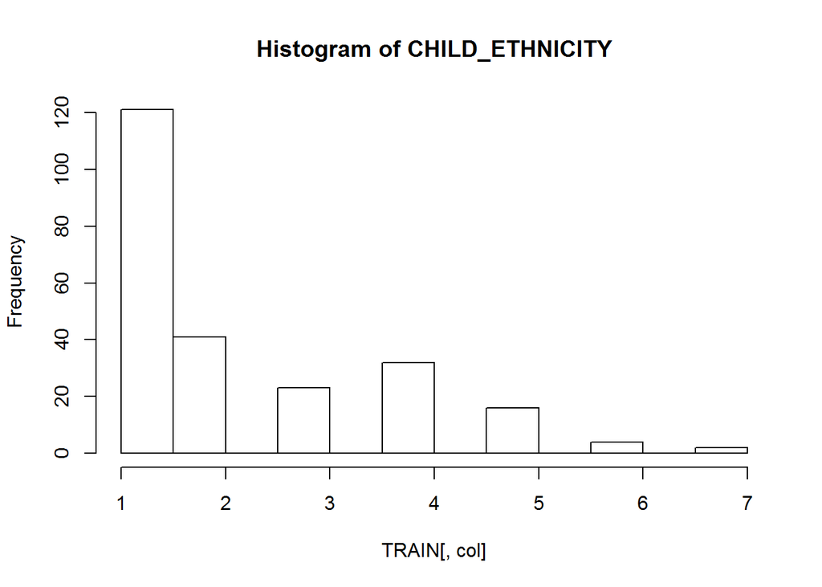

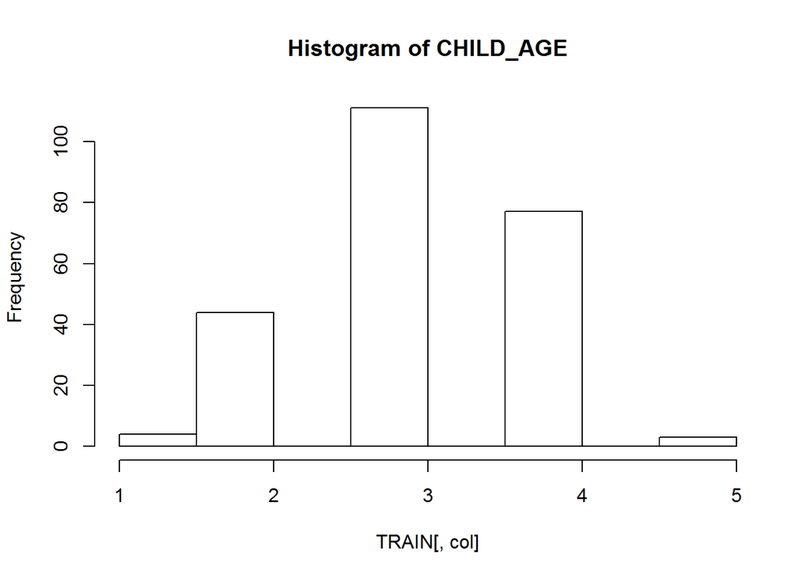

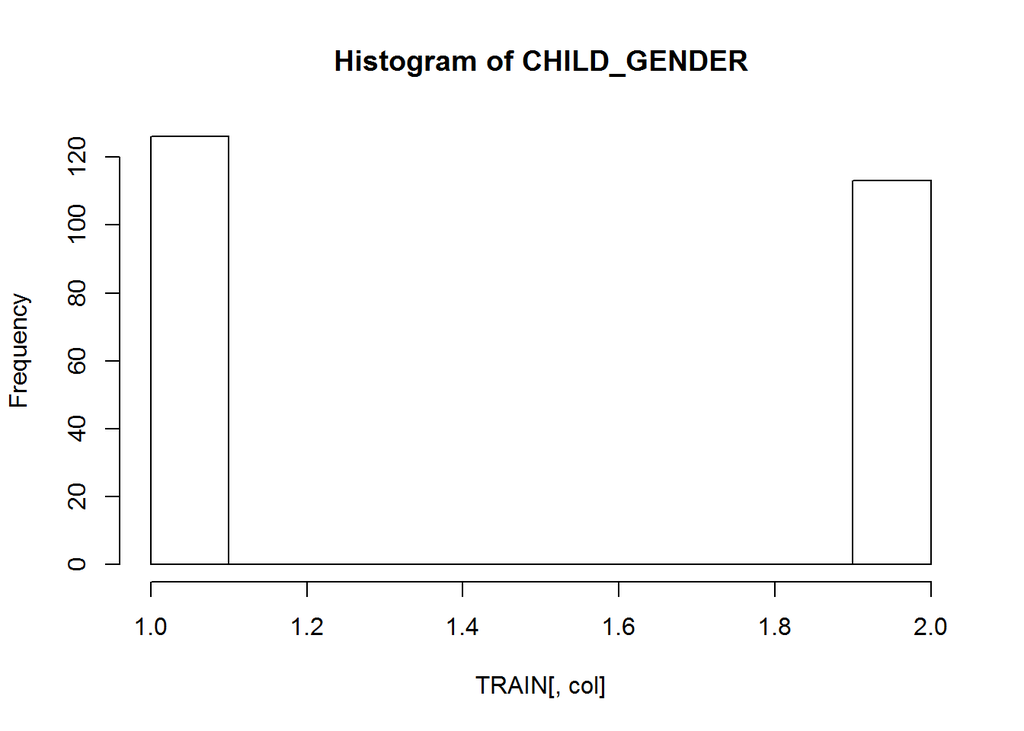

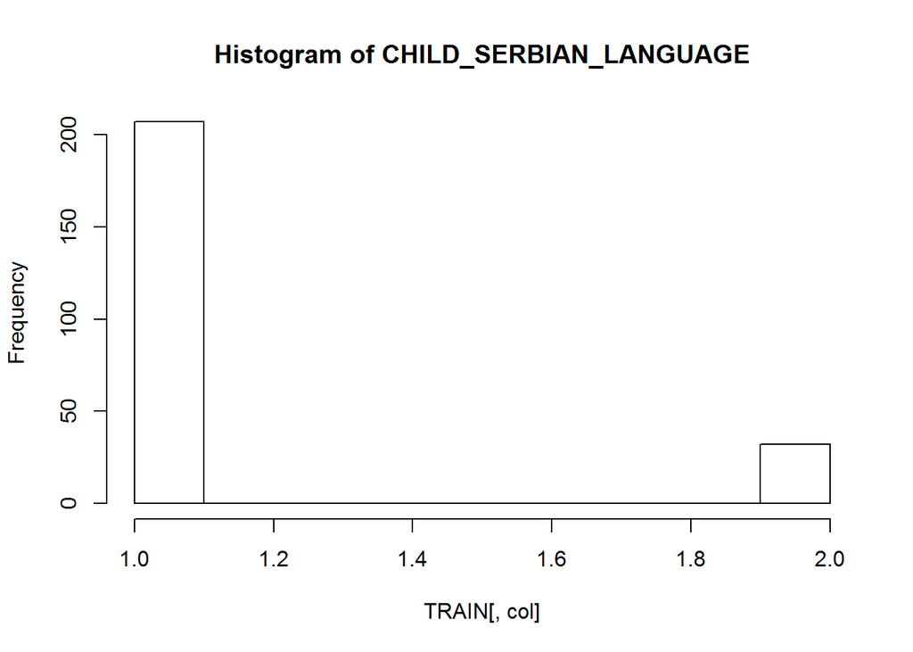

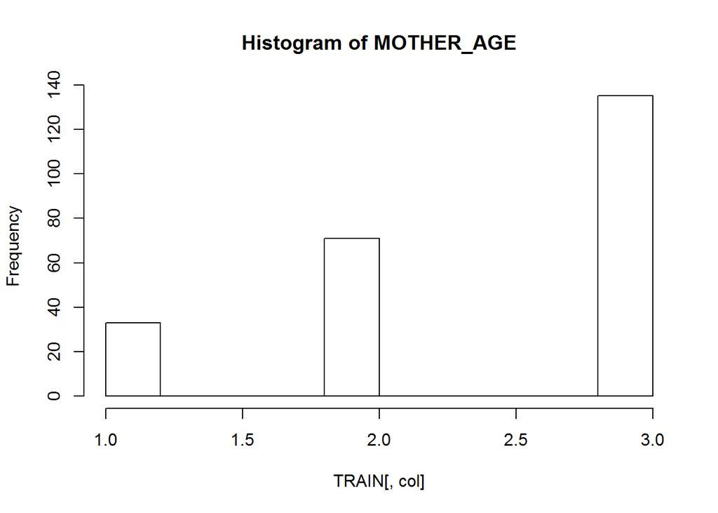

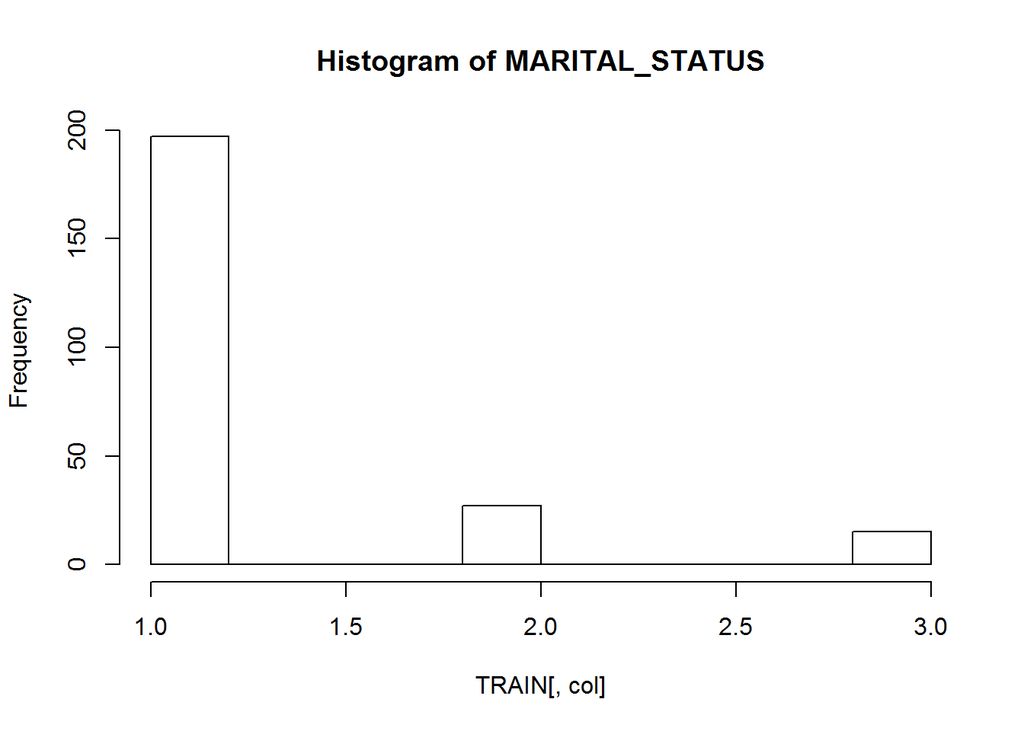

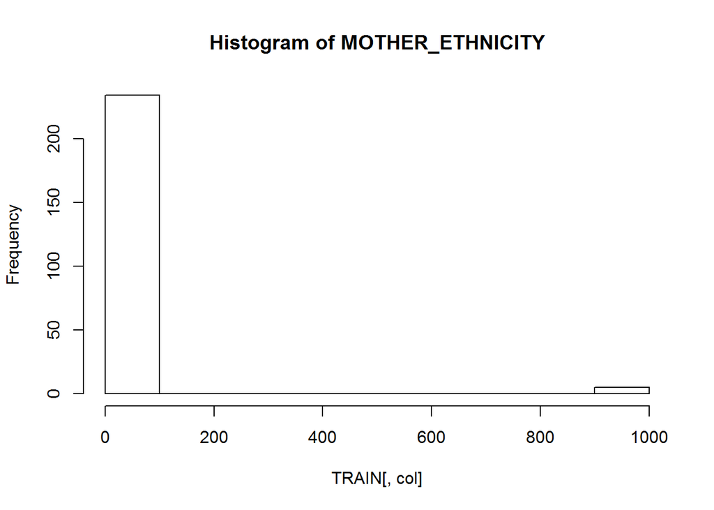

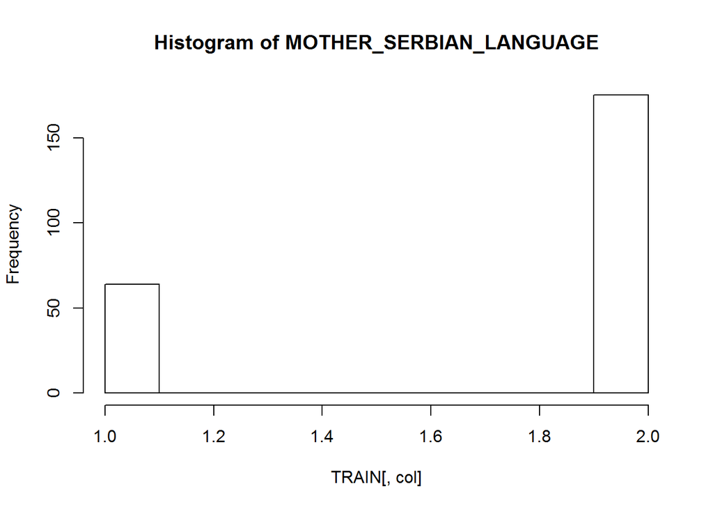

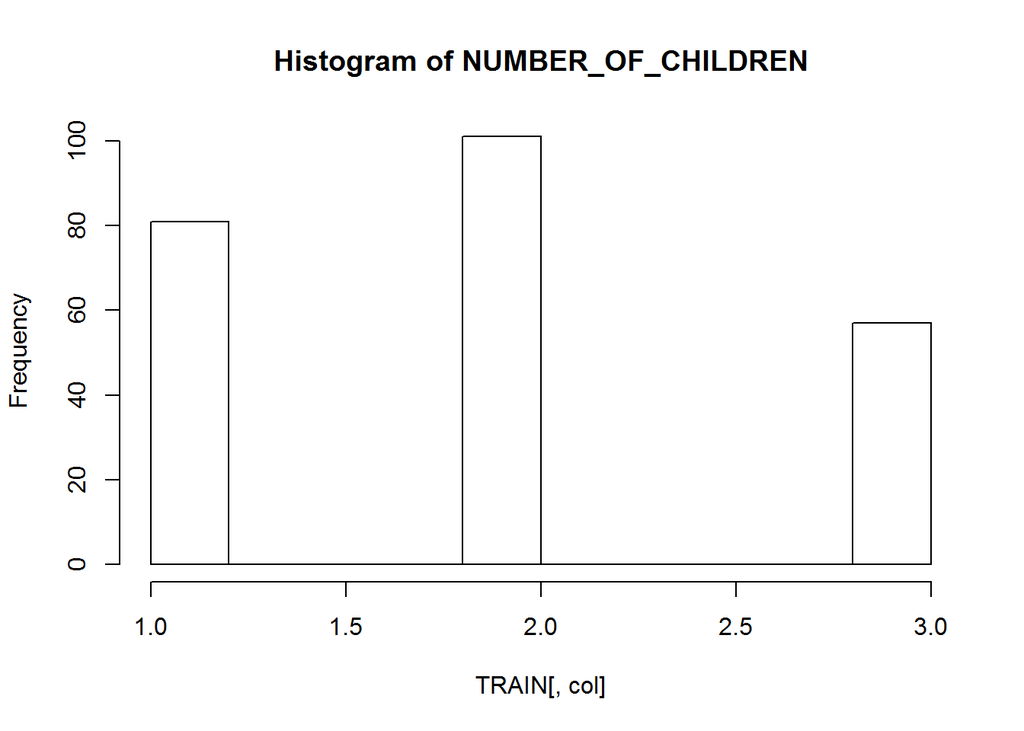

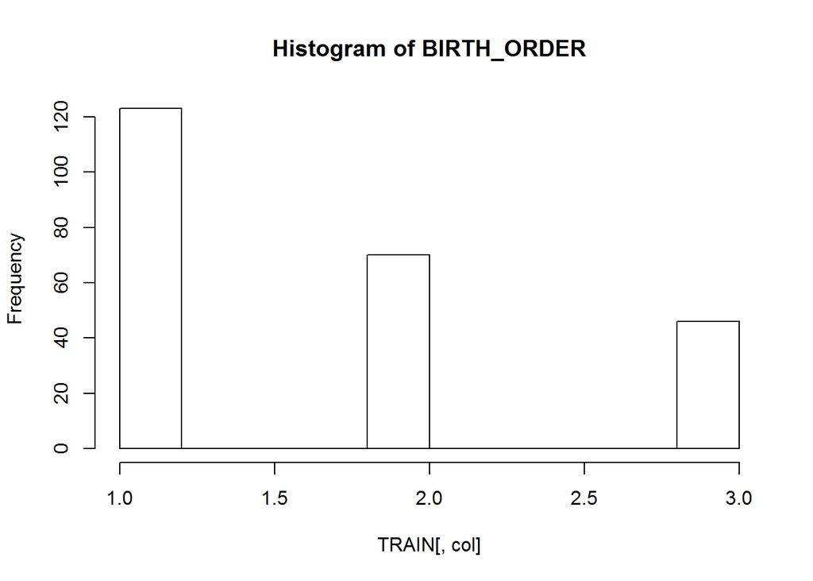

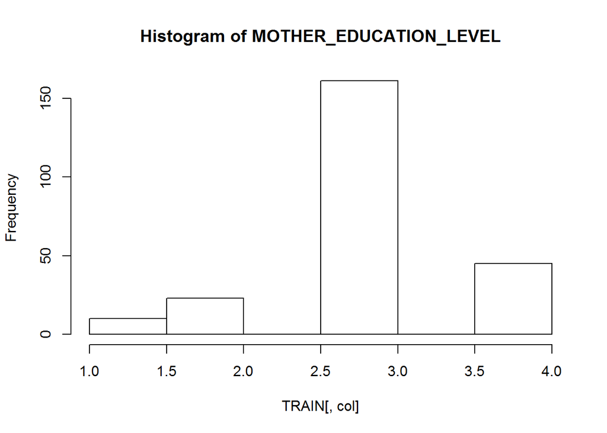

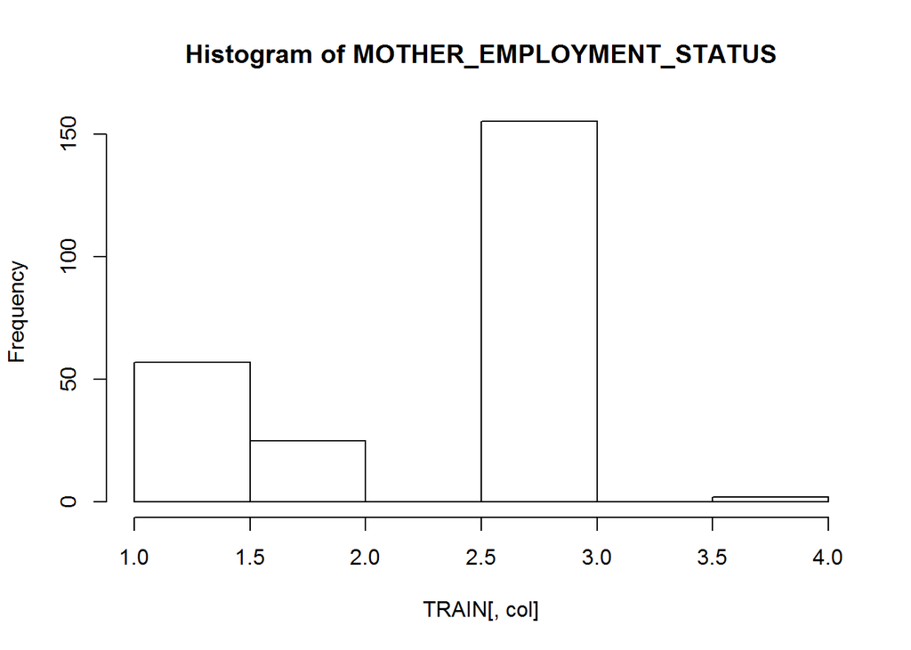

[23 more figures not shown]

```r
for (col in 2:ncol(TRAIN)) {
  hist(TRAIN[,col], main = paste("Histogram of", colnames(TRAIN)[col]))
}
```

- All the distributions of attributes are observed and the problems with the attributes having ‘999’ values are observed.
- Most of the attributes have ordinal characteristics and very few classes. This situation can be observed from the histograms.

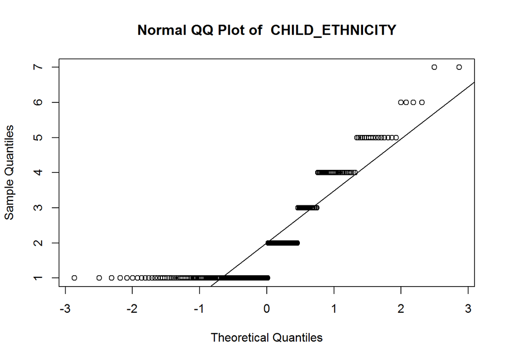

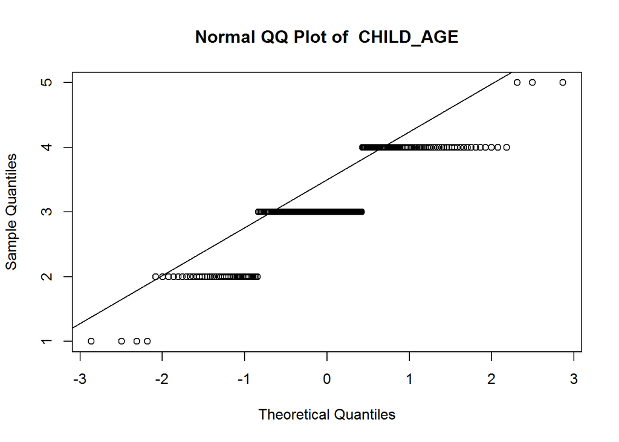

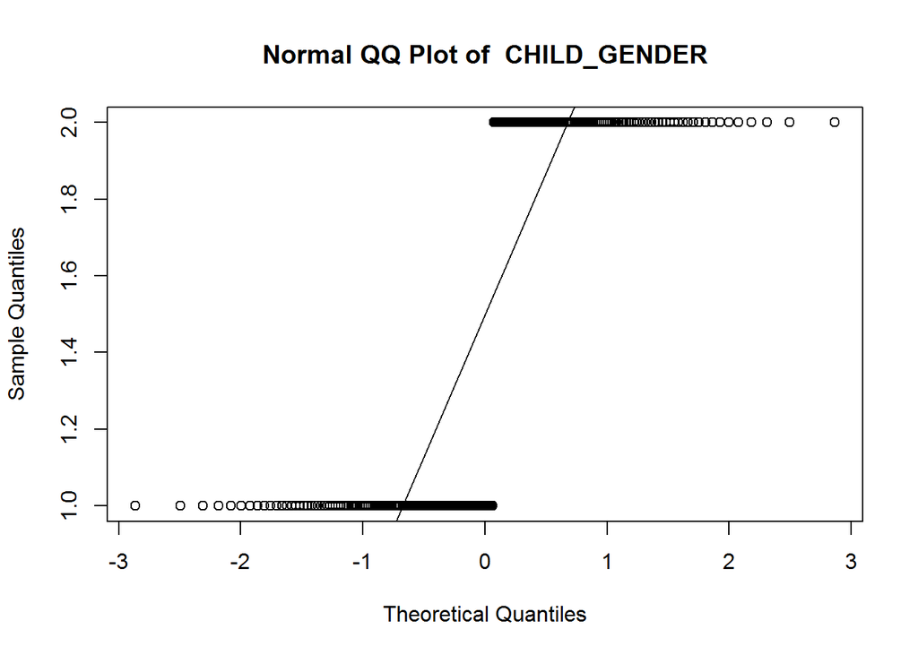

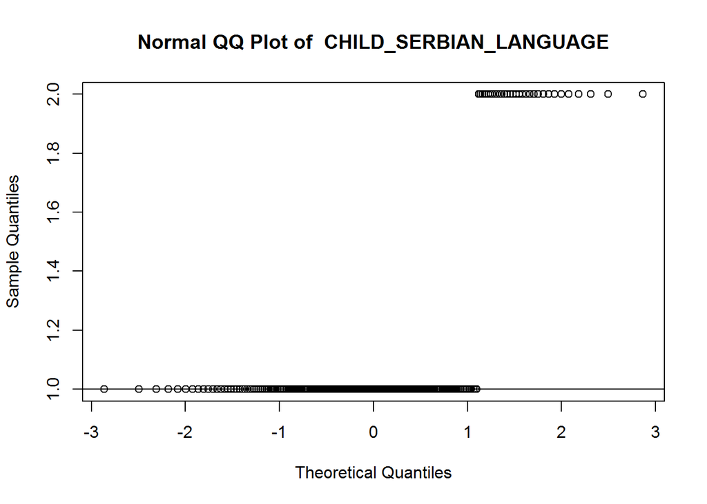

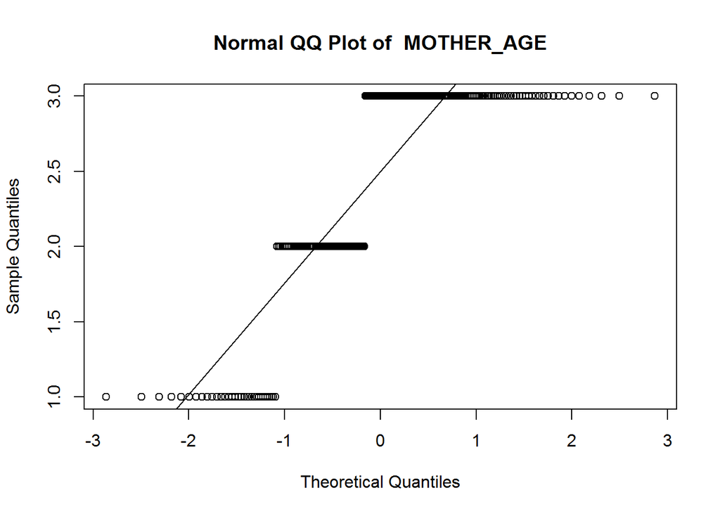

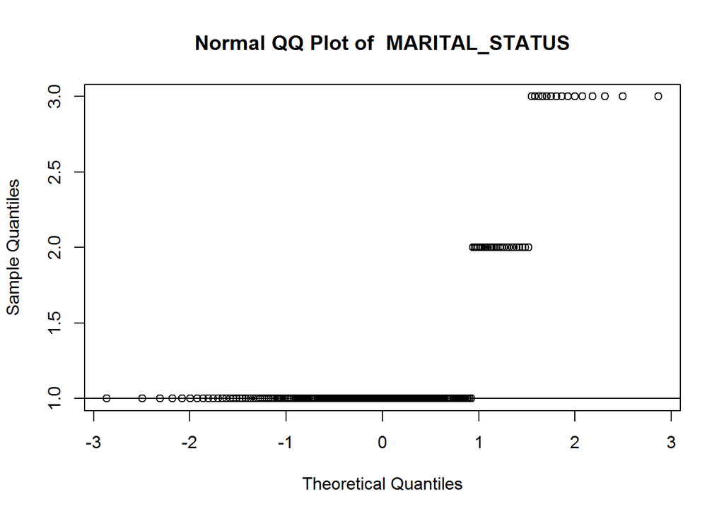

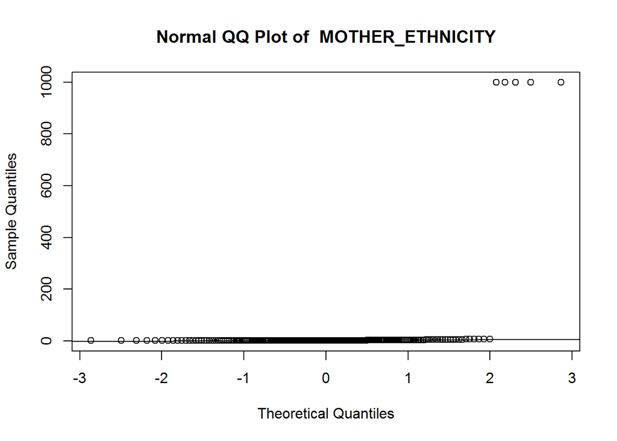

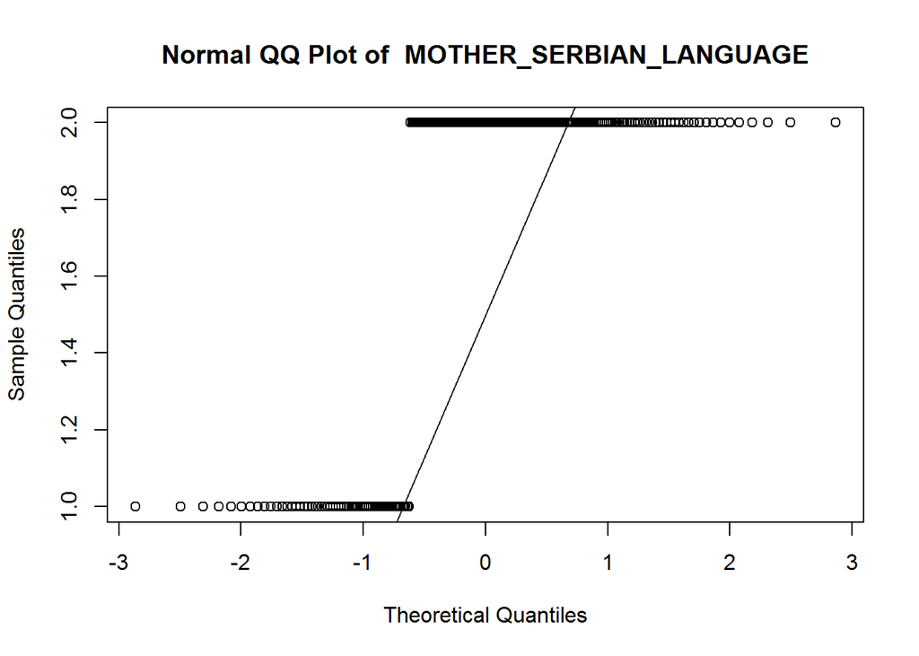

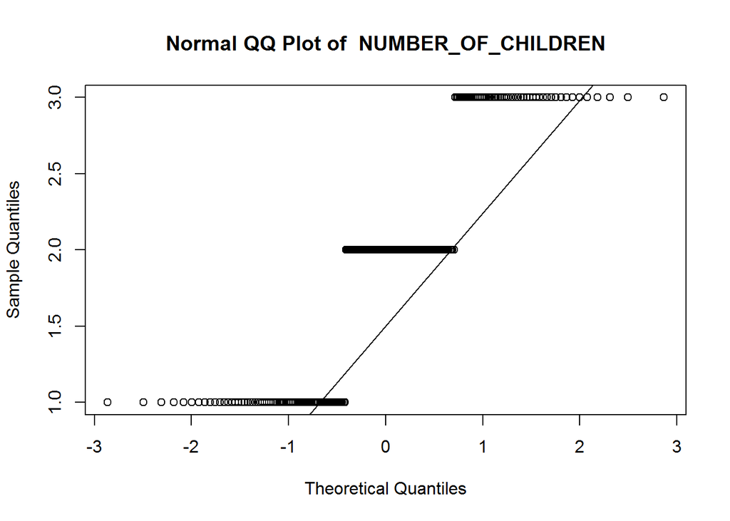

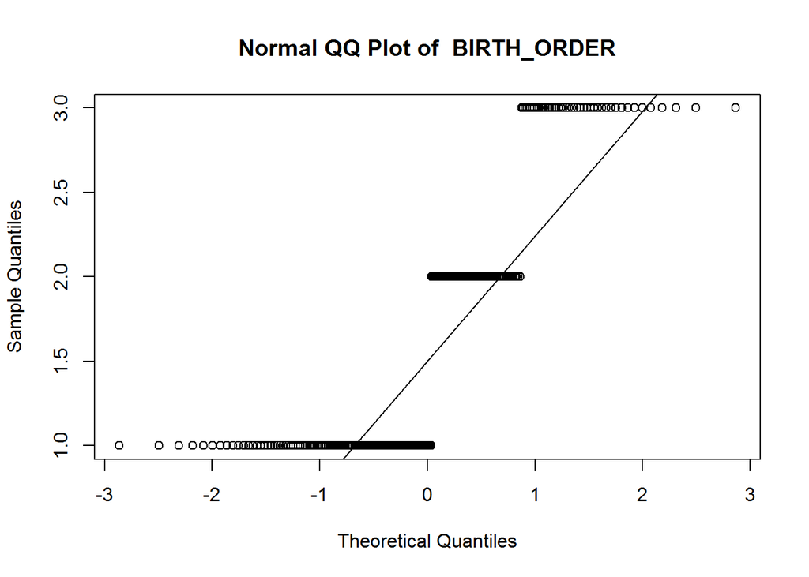

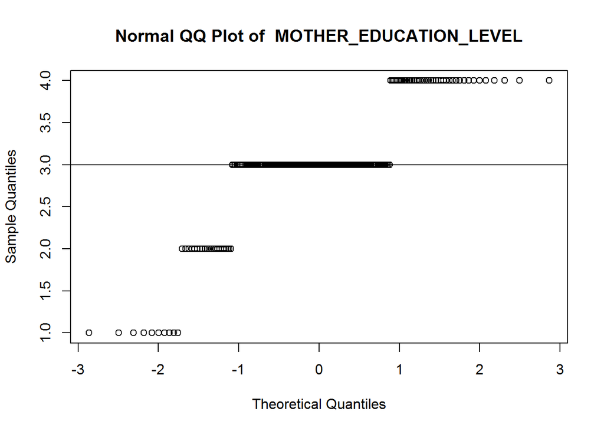

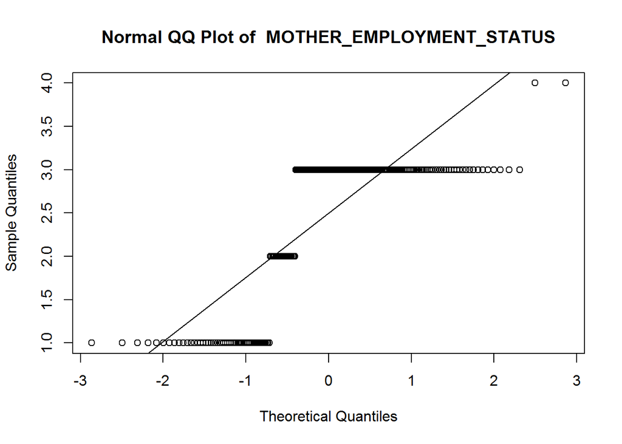

[23 more figures not shown]

```r
for (col in 2:ncol(TRAIN)) {
  qqnorm(TRAIN[,col], main = paste("Normal QQ Plot of ",colnames(TRAIN)[col])); qqline(TRAIN[,col])
}
```

- The Q-Q plots give a strong idea about the closeness of an attribute to the normal one. If the data is normally distributed, the points in the QQ-normal plot lie on a straight diagonal line.
- As most of our data is type of nominal, it is not expected to have a normal data distribution in attributes. But still, It is possible to observe the dsitribution of nominal data labels in these Q-Q plots.

## Descriptive Location Measures for Each of the Numerical Attributes

### Geometric Mean:

- We already achieved mean and median values of each attributes with summary() command.
- Besides that, geometric mean is an important measure of the central tendency.

```r
geomean = matrix(0,36,1)
for (col in 2:ncol(TRAIN)) {
  geomean[col] = exp(mean(log(TRAIN[,col])))
}
#geomean
geomean_vector <- data.frame(geomean)
row.names(geomean_vector) <- colnames(TRAIN)
kable(geomean_vector,row.names = TRUE)
```

|  | geomean |
| --- | --- |
| CITY | 0.000000 |
| CHILD_ETHNICITY | 1.758148 |
| CHILD_AGE | 3.018245 |
| CHILD_GENDER | 1.387803 |
| CHILD_SERBIAN_LANGUAGE | 1.097249 |
| MOTHER_AGE | 2.285236 |
| MARITAL_STATUS | 1.158650 |
| MOTHER_ETHNICITY | 1.887356 |
| MOTHER_SERBIAN_LANGUAGE | 1.661191 |
| NUMBER_OF_CHILDREN | 1.741823 |
| BIRTH_ORDER | 1.513556 |
| MOTHER_EDUCATION_LEVEL | 2.908949 |
| MOTHER_EMPLOYMENT_STATUS | 2.217976 |
| QUALITY_OF_HOUSING | 1.632377 |
| HOUSING_CONDITIONS | 1.072084 |
| HOUSEHOLD_MONTHLY_INCOME | 3.108337 |
| BIRTH_WEIGHT | 1.876377 |
| BREASTFEEDING | 1.754348 |
| BREASTFEEDING_FREQUENCY | 4.413374 |
| BREASTFEEDING_DURING_NIGHT | 2.084179 |
| BOTTLE_FEEDING | 2.240267 |
| INFANT_FORMULAS | 1.479237 |
| ADDITIONAL_FOOD_SWEETENING | 2.165548 |
| CHILD_FLUORIDE_SUPPLEMENTS | 2.638544 |
| CHILD_FLUORIDE_TOOTHPASTE | 1.272027 |
| CHILD_ORAL_HYGIENE | 1.799259 |
| CHILD_TOOTH_BRUSHING | 1.968312 |
| DIARRHEA_DURING_INFANCY | 1.865525 |
| MEDICAL_SYRUPS | 2.368098 |
| CHILD_FIRST_DENTIST_VISIT | 2.985174 |
| SWEETS_DURING_PREGNANCY | 1.783182 |
| FLUORIDE_SUPPLEMENTS_DURING_PREGNANCY | 2.259006 |
| ORAL_HEALTH_DURING_PREGNANCY | 1.650330 |
| MOTHER_HEALTH_AWARENESS | 1.992148 |
| FATHER_HEALTH_AWARENESS | 1.783284 |
| ECC | 1.627806 |

Besides the central tendency, the fact that how closely the data fall about the center is another issue. We need to figure out the spread pattern around the center.

### Range:

```r
rangeVector = matrix(0,36,1)
for (col in 2:ncol(TRAIN)) {
  rangeVector[col] = max(TRAIN[,col], na.rm = TRUE)-min(TRAIN[,col], na.rm = TRUE)
}

range_Vector <- data.frame(rangeVector)
row.names(range_Vector) <- colnames(TRAIN)
kable(range_Vector,row.names = TRUE)
```

|  | rangeVector |
| --- | --- |
| CITY | 0 |
| CHILD_ETHNICITY | 6 |
| CHILD_AGE | 4 |
| CHILD_GENDER | 1 |
| CHILD_SERBIAN_LANGUAGE | 1 |
| MOTHER_AGE | 2 |
| MARITAL_STATUS | 2 |
| MOTHER_ETHNICITY | 998 |
| MOTHER_SERBIAN_LANGUAGE | 1 |
| NUMBER_OF_CHILDREN | 2 |
| BIRTH_ORDER | 2 |
| MOTHER_EDUCATION_LEVEL | 3 |
| MOTHER_EMPLOYMENT_STATUS | 3 |
| QUALITY_OF_HOUSING | 2 |
| HOUSING_CONDITIONS | 1 |
| HOUSEHOLD_MONTHLY_INCOME | 4 |
| BIRTH_WEIGHT | 1 |
| BREASTFEEDING | 3 |
| BREASTFEEDING_FREQUENCY | 998 |
| BREASTFEEDING_DURING_NIGHT | 998 |
| BOTTLE_FEEDING | 3 |
| INFANT_FORMULAS | 1 |
| ADDITIONAL_FOOD_SWEETENING | 2 |
| CHILD_FLUORIDE_SUPPLEMENTS | 2 |
| CHILD_FLUORIDE_TOOTHPASTE | 2 |
| CHILD_ORAL_HYGIENE | 2 |
| CHILD_TOOTH_BRUSHING | 3 |
| DIARRHEA_DURING_INFANCY | 1 |
| MEDICAL_SYRUPS | 2 |
| CHILD_FIRST_DENTIST_VISIT | 3 |
| SWEETS_DURING_PREGNANCY | 2 |
| FLUORIDE_SUPPLEMENTS_DURING_PREGNANCY | 2 |
| ORAL_HEALTH_DURING_PREGNANCY | 2 |
| MOTHER_HEALTH_AWARENESS | 2 |
| FATHER_HEALTH_AWARENESS | 2 |
| ECC | 1 |

### Interquantile Range

```r
iqc = matrix(0,36,1)
for (col in 2:ncol(TRAIN)) {
  iqc[col] = IQR(TRAIN[,col])
}

iqr_vector <- data.frame(iqc)
row.names(iqr_vector) <- colnames(TRAIN)
kable(iqr_vector, row.names = TRUE)
```

|  | iqc |
| --- | --- |
| CITY | 0 |
| CHILD_ETHNICITY | 2 |
| CHILD_AGE | 1 |
| CHILD_GENDER | 1 |
| CHILD_SERBIAN_LANGUAGE | 0 |
| MOTHER_AGE | 1 |
| MARITAL_STATUS | 0 |
| MOTHER_ETHNICITY | 2 |
| MOTHER_SERBIAN_LANGUAGE | 1 |
| NUMBER_OF_CHILDREN | 1 |
| BIRTH_ORDER | 1 |
| MOTHER_EDUCATION_LEVEL | 0 |
| MOTHER_EMPLOYMENT_STATUS | 1 |
| QUALITY_OF_HOUSING | 2 |
| HOUSING_CONDITIONS | 0 |
| HOUSEHOLD_MONTHLY_INCOME | 1 |
| BIRTH_WEIGHT | 0 |
| BREASTFEEDING | 2 |
| BREASTFEEDING_FREQUENCY | 1 |
| BREASTFEEDING_DURING_NIGHT | 0 |
| BOTTLE_FEEDING | 1 |
| INFANT_FORMULAS | 1 |
| ADDITIONAL_FOOD_SWEETENING | 1 |
| CHILD_FLUORIDE_SUPPLEMENTS | 1 |
| CHILD_FLUORIDE_TOOTHPASTE | 1 |
| CHILD_ORAL_HYGIENE | 0 |
| CHILD_TOOTH_BRUSHING | 1 |
| DIARRHEA_DURING_INFANCY | 0 |
| MEDICAL_SYRUPS | 1 |
| CHILD_FIRST_DENTIST_VISIT | 2 |
| SWEETS_DURING_PREGNANCY | 0 |
| FLUORIDE_SUPPLEMENTS_DURING_PREGNANCY | 1 |
| ORAL_HEALTH_DURING_PREGNANCY | 1 |
| MOTHER_HEALTH_AWARENESS | 0 |
| FATHER_HEALTH_AWARENESS | 0 |
| ECC | 1 |

### Variance

```r
variance = matrix(0,36,1)

for (col in 2:ncol(TRAIN)) {
  variance[col] = var(TRAIN[,col])
}
var_vector <- data.frame(variance)
row.names(var_vector) <- colnames(TRAIN)
kable(var_vector, row.names = TRUE)
```

|  | variance |
| --- | --- |
| CITY | 0.000000e+00 |
| CHILD_ETHNICITY | 2.198762e+00 |
| CHILD_AGE | 6.091558e-01 |
| CHILD_GENDER | 2.503077e-01 |
| CHILD_SERBIAN_LANGUAGE | 1.164516e-01 |
| MOTHER_AGE | 5.229774e-01 |
| MARITAL_STATUS | 3.084280e-01 |
| MOTHER_ETHNICITY | 2.044553e+04 |
| MOTHER_SERBIAN_LANGUAGE | 1.968988e-01 |
| NUMBER_OF_CHILDREN | 5.697057e-01 |
| BIRTH_ORDER | 6.058507e-01 |
| MOTHER_EDUCATION_LEVEL | 4.537112e-01 |
| MOTHER_EMPLOYMENT_STATUS | 7.414648e-01 |
| QUALITY_OF_HOUSING | 8.175521e-01 |
| HOUSING_CONDITIONS | 9.071410e-02 |
| HOUSEHOLD_MONTHLY_INCOME | 1.194016e+00 |
| BIRTH_WEIGHT | 8.392810e-02 |
| BREASTFEEDING | 1.058823e+00 |
| BREASTFEEDING_FREQUENCY | 1.032018e+05 |
| BREASTFEEDING_DURING_NIGHT | 8.356663e+04 |
| BOTTLE_FEEDING | 8.254984e-01 |
| INFANT_FORMULAS | 2.468268e-01 |
| ADDITIONAL_FOOD_SWEETENING | 4.954116e-01 |
| CHILD_FLUORIDE_SUPPLEMENTS | 2.752013e-01 |
| CHILD_FLUORIDE_TOOTHPASTE | 4.841954e-01 |
| CHILD_ORAL_HYGIENE | 2.583243e-01 |
| CHILD_TOOTH_BRUSHING | 7.557751e-01 |
| DIARRHEA_DURING_INFANCY | 9.071410e-02 |
| MEDICAL_SYRUPS | 2.618403e-01 |
| CHILD_FIRST_DENTIST_VISIT | 8.653704e-01 |
| SWEETS_DURING_PREGNANCY | 2.179600e-01 |
| FLUORIDE_SUPPLEMENTS_DURING_PREGNANCY | 6.160121e-01 |
| ORAL_HEALTH_DURING_PREGNANCY | 5.309237e-01 |
| MOTHER_HEALTH_AWARENESS | 2.486551e-01 |
| FATHER_HEALTH_AWARENESS | 3.035055e-01 |
| ECC | 2.096973e-01 |

### Coefficient of Variance

```r
CV = matrix(0,36,1)
for (col in 2:ncol(TRAIN)) {
  CV[col] = sd(TRAIN[,col], na.rm=TRUE)/mean(TRAIN[,col], na.rm=TRUE)*100
}
CV_vector <- data.frame(CV)
row.names(CV_vector) <- colnames(TRAIN)
kable(CV_vector, row.names = TRUE)
```

|  | CV |
| --- | --- |
| CITY | 0.00000 |
| CHILD_ETHNICITY | 68.41594 |
| CHILD_AGE | 24.93794 |
| CHILD_GENDER | 33.96975 |
| CHILD_SERBIAN_LANGUAGE | 30.09548 |
| MOTHER_AGE | 29.79966 |
| MARITAL_STATUS | 44.84180 |
| MOTHER_ETHNICITY | 624.07043 |
| MOTHER_SERBIAN_LANGUAGE | 25.61646 |
| NUMBER_OF_CHILDREN | 39.73446 |
| BIRTH_ORDER | 46.39128 |
| MOTHER_EDUCATION_LEVEL | 22.39024 |
| MOTHER_EMPLOYMENT_STATUS | 35.48258 |
| QUALITY_OF_HOUSING | 48.89150 |
| HOUSING_CONDITIONS | 27.37030 |
| HOUSEHOLD_MONTHLY_INCOME | 32.64472 |
| BIRTH_WEIGHT | 15.18402 |
| BREASTFEEDING | 51.44958 |
| BREASTFEEDING_FREQUENCY | 270.01530 |
| BREASTFEEDING_DURING_NIGHT | 310.80960 |
| BOTTLE_FEEDING | 37.43933 |
| INFANT_FORMULAS | 31.74844 |
| ADDITIONAL_FOOD_SWEETENING | 30.64140 |
| CHILD_FLUORIDE_SUPPLEMENTS | 19.37844 |
| CHILD_FLUORIDE_TOOTHPASTE | 49.79225 |
| CHILD_ORAL_HYGIENE | 27.05417 |
| CHILD_TOOTH_BRUSHING | 40.50203 |
| DIARRHEA_DURING_INFANCY | 15.85548 |
| MEDICAL_SYRUPS | 21.12212 |
| CHILD_FIRST_DENTIST_VISIT | 29.44774 |
| SWEETS_DURING_PREGNANCY | 25.18735 |
| FLUORIDE_SUPPLEMENTS_DURING_PREGNANCY | 32.28616 |
| ORAL_HEALTH_DURING_PREGNANCY | 40.49911 |
| MOTHER_HEALTH_AWARENESS | 24.22320 |
| FATHER_HEALTH_AWARENESS | 29.39024 |
| ECC | 26.89056 |

- Coefficient of variance is a better parameter to see the behaviour of the data. Because it gives more logical results in the attributes with different scales.

### Correlation & Covariance

- Correlation and Covariance matrixes will be very helpful in our Feature Selection process. It is not wise to use two highly correlated attributes in the same model. Because, this situation would result with overfitting problems.

```r
options(knitr.kable.NA = '')
NUM=data.frame(TRAIN[2:36])

# correlations/covariance
kable(cov(NUM))
```

|  | CHILD_ETHNICITY | CHILD_AGE | CHILD_GENDER | CHILD_SERBIAN_LANGUAGE | MOTHER_AGE | MARITAL_STATUS | MOTHER_ETHNICITY | MOTHER_SERBIAN_LANGUAGE | NUMBER_OF_CHILDREN | BIRTH_ORDER | MOTHER_EDUCATION_LEVEL | MOTHER_EMPLOYMENT_STATUS | QUALITY_OF_HOUSING | HOUSING_CONDITIONS | HOUSEHOLD_MONTHLY_INCOME | BIRTH_WEIGHT | BREASTFEEDING | BREASTFEEDING_FREQUENCY | BREASTFEEDING_DURING_NIGHT | BOTTLE_FEEDING | INFANT_FORMULAS | ADDITIONAL_FOOD_SWEETENING | CHILD_FLUORIDE_SUPPLEMENTS | CHILD_FLUORIDE_TOOTHPASTE | CHILD_ORAL_HYGIENE | CHILD_TOOTH_BRUSHING | DIARRHEA_DURING_INFANCY | MEDICAL_SYRUPS | CHILD_FIRST_DENTIST_VISIT | … |
| --- | --- | --- | --- | --- | --- | --- | --- | --- | --- | --- | --- | --- | --- | --- | --- | --- | --- | --- | --- | --- | --- | --- | --- | --- | --- | --- | --- | --- | --- | --- |
| CHILD_ETHNICITY | 2.1987624 | -0.2024718 | 0.0339826 | 0.1581695 | -0.2397947 | 0.0481523 | 52.6828346 | -0.1776836 | 0.2899863 | 0.3062480 | -0.5056081 | -0.4834921 | 0.1135509 | 0.1806019 | -0.7306354 | -0.0727647 | 0.2857143 | 4.749161e+01 | 1.3431314 | 0.0333146 | -0.0403115 | 0.0467107 | 0.0702331 | 0.2147076 | 0.1758553 | 0.2232868 | -0.1511902 | 0.0760346 | 0.2295805 | … |
| CHILD_AGE | -0.2024718 | 0.6091558 | 0.0266517 | -0.0300447 | 0.1040751 | 0.0109525 | 9.6080834 | 0.0138708 | -0.0079287 | -0.0336662 | 0.0703386 | 0.0788650 | -0.0434056 | -0.0256848 | 0.1480433 | 0.0119897 | -0.0672269 | -1.105976e+01 | -7.7784009 | -0.0303787 | 0.0440737 | -0.0134841 | -0.0416828 | -0.0391688 | -0.0178088 | -0.1661334 | 0.0130797 | -0.0340354 | -0.1005415 | … |
| CHILD_GENDER | 0.0339826 | 0.0266517 | 0.2503077 | -0.0131500 | -0.0639745 | 0.0086143 | -5.6851728 | -0.0325235 | 0.0056608 | -0.0151014 | -0.0207799 | -0.0051510 | 0.0421047 | 0.0111459 | 0.0073837 | -0.0025140 | -0.0336134 | -1.356791e+01 | -14.2560740 | 0.0368658 | 0.0007208 | 0.0060124 | -0.0164024 | 0.0087550 | -0.0012130 | -0.0485215 | 0.0056608 | -0.0199712 | -0.0208678 | … |
| CHILD_SERBIAN_LANGUAGE | 0.1581695 | -0.0300447 | -0.0131500 | 0.1164516 | -0.0447769 | 0.0057487 | -2.6184382 | -0.0228192 | 0.0555184 | 0.0559228 | -0.0725537 | -0.0615836 | 0.0160508 | 0.0159101 | -0.0887100 | -0.0128336 | 0.0000000 | -3.126877e+00 | -3.9717134 | 0.0014416 | -0.0087198 | 0.0188812 | 0.0099680 | 0.0137829 | 0.0247178 | 0.0223269 | -0.0243135 | -0.0148026 | 0.0626560 | … |
| MOTHER_AGE | -0.2397947 | 0.1040751 | -0.0639745 | -0.0447769 | 0.5229774 | -0.0517914 | 3.3317746 | 0.0601420 | 0.0304314 | 0.0708484 | 0.1728842 | 0.1742379 | -0.1245209 | -0.0724482 | 0.2713336 | 0.0562568 | -0.0378151 | 1.662213e-01 | 6.7569178 | -0.0064344 | -0.0067860 | 0.0533561 | -0.0467459 | -0.0905207 | -0.0782497 | -0.0585598 | 0.0514398 | 0.0121655 | -0.0723427 | … |
| MARITAL_STATUS | 0.0481523 | 0.0109525 | 0.0086143 | 0.0057487 | -0.0517914 | 0.3084280 | 3.4160015 | -0.0535143 | -0.0305721 | -0.0194789 | -0.0482226 | -0.0349847 | 0.0276713 | 0.0347737 | -0.0789705 | 0.0052389 | 0.0294118 | 1.392198e+01 | 7.3551387 | -0.0223797 | -0.0050280 | -0.0081221 | 0.0113217 | 0.0434584 | 0.0710770 | 0.0951795 | -0.0221687 | -0.0675961 | 0.0291481 | … |
| MOTHER_ETHNICITY | 52.6828346 | 9.6080834 | -5.6851728 | -2.6184382 | 3.3317746 | 3.4160015 | 20445.5258606 | 1.2410780 | 2.3230723 | 2.7782954 | -0.6589255 | -1.0085616 | -0.9502655 | -1.9113076 | 4.5684575 | 1.8406174 | 4.4117647 | 1.753670e+03 | -1927.9782532 | -0.5337717 | -3.4669667 | 2.2320945 | 1.9909637 | 0.2367533 | -1.4686896 | -2.8484231 | -2.2147428 | -0.3912837 | 1.0518442 | … |
| MOTHER_SERBIAN_LANGUAGE | -0.1776836 | 0.0138708 | -0.0325235 | -0.0228192 | 0.0601420 | -0.0535143 | 1.2410780 | 0.1968988 | -0.0732218 | -0.0446187 | 0.0694772 | 0.0937555 | -0.0363032 | -0.0402236 | 0.1101930 | 0.0172638 | -0.0084034 | 6.266358e+00 | 3.7417461 | -0.0196899 | 0.0216413 | -0.0251573 | -0.0241377 | -0.0611793 | -0.0536374 | -0.0866707 | 0.0234169 | -0.0040083 | -0.0412784 | … |
| NUMBER_OF_CHILDREN | 0.2899863 | -0.0079287 | 0.0056608 | 0.0555184 | 0.0304314 | -0.0305721 | 2.3230723 | -0.0732218 | 0.5697057 | 0.4759151 | -0.1504167 | -0.2174677 | 0.0604409 | 0.0689498 | -0.2885095 | -0.0260891 | -0.0420168 | -9.124380e+00 | -11.7260469 | 0.0304314 | 0.0065399 | -0.0036567 | 0.0166837 | 0.0064695 | 0.0591927 | 0.0483809 | -0.0521430 | 0.0005977 | 0.1714954 | … |
| BIRTH_ORDER | 0.3062480 | -0.0336662 | -0.0151014 | 0.0559228 | 0.0708484 | -0.0194789 | 2.7782954 | -0.0446187 | 0.4759151 | 0.6058507 | -0.1527548 | -0.2064625 | 0.0437045 | 0.0661018 | -0.2657959 | 0.0038325 | -0.0042017 | -4.066946e+00 | -8.0309061 | 0.0162266 | 0.0020745 | 0.0204810 | 0.0102844 | 0.0025491 | 0.0783904 | 0.0893956 | -0.0408917 | -0.0313456 | 0.1186667 | … |
| MOTHER_EDUCATION_LEVEL | -0.5056081 | 0.0703386 | -0.0207799 | -0.0725537 | 0.1728842 | -0.0482226 | -0.6589255 | 0.0694772 | -0.1504167 | -0.1527548 | 0.4537112 | 0.2989346 | -0.1247846 | -0.1016842 | 0.4634682 | 0.0427903 | -0.0546218 | -9.432562e+00 | -0.7563728 | 0.0342288 | 0.0120601 | 0.0563271 | -0.0521606 | -0.1083823 | -0.0998207 | -0.1188777 | 0.0890791 | -0.0287613 | -0.1399916 | … |
| MOTHER_EMPLOYMENT_STATUS | -0.4834921 | 0.0788650 | -0.0051510 | -0.0615836 | 0.1742379 | -0.0349847 | -1.0085616 | 0.0937555 | -0.2174677 | -0.2064625 | 0.2989346 | 0.7414648 | -0.1287226 | -0.1102634 | 0.5192328 | 0.0646602 | 0.0126050 | 8.527566e+00 | 15.1098590 | 0.0439858 | 0.0268275 | 0.0953729 | -0.0593509 | -0.1031258 | -0.0740480 | -0.0837699 | 0.0766499 | 0.0037622 | -0.1521747 | … |
| QUALITY_OF_HOUSING | 0.1135509 | -0.0434056 | 0.0421047 | 0.0160508 | -0.1245209 | 0.0276713 | -0.9502655 | -0.0363032 | 0.0604409 | 0.0437045 | -0.1247846 | -0.1287226 | 0.8175521 | 0.0488028 | -0.2037727 | -0.0265286 | 0.0546218 | -7.444974e+00 | -11.2382300 | -0.0488907 | -0.0111986 | 0.0239267 | 0.0691431 | 0.0349144 | 0.0110580 | 0.0431595 | -0.0277944 | 0.0303084 | 0.0198481 | … |
| HOUSING_CONDITIONS | 0.1806019 | -0.0256848 | 0.0111459 | 0.0159101 | -0.0724482 | 0.0347737 | -1.9113076 | -0.0402236 | 0.0689498 | 0.0661018 | -0.1016842 | -0.1102634 | 0.0488028 | 0.0907141 | -0.1358602 | -0.0159277 | 0.0420168 | 8.008509e-01 | -5.0638691 | 0.0073837 | -0.0065399 | 0.0120601 | 0.0253331 | 0.0649590 | 0.0626560 | 0.0692662 | -0.0444956 | 0.0036040 | 0.0427903 | … |
| HOUSEHOLD_MONTHLY_INCOME | -0.7306354 | 0.1480433 | 0.0073837 | -0.0887100 | 0.2713336 | -0.0789705 | 4.5684575 | 0.1101930 | -0.2885095 | -0.2657959 | 0.4634682 | 0.5192328 | -0.2037727 | -0.1358602 | 1.1940157 | 0.0993284 | -0.0588235 | -2.405427e+01 | -6.8810696 | 0.0738546 | 0.0509124 | 0.1400970 | -0.0323125 | -0.1596287 | -0.0879364 | -0.1309026 | 0.1442636 | -0.0381316 | -0.2445238 | … |
| BIRTH_WEIGHT | -0.0727647 | 0.0119897 | -0.0025140 | -0.0128336 | 0.0562568 | 0.0052389 | 1.8406174 | 0.0172638 | -0.0260891 | 0.0038325 | 0.0427903 | 0.0646602 | -0.0265286 | -0.0159277 | 0.0993284 | 0.0839281 | 0.0000000 | -1.783833e+00 | 0.1058155 | 0.0058366 | 0.0059949 | 0.0022503 | 0.0065399 | -0.0094758 | -0.0112162 | 0.0177385 | 0.0201294 | -0.0113568 | 0.0020921 | … |
| BREASTFEEDING | 0.2857143 | -0.0672269 | -0.0336134 | 0.0000000 | -0.0378151 | 0.0294118 | 4.4117647 | -0.0084034 | -0.0420168 | -0.0042017 | -0.0546218 | 0.0126050 | 0.0546218 | 0.0420168 | -0.0588235 | 0.0000000 | 1.0588235 | 2.220378e+02 | 184.4873950 | -0.1722689 | 0.0210084 | 0.0672269 | 0.0294118 | 0.0714286 | 0.0000000 | 0.1470588 | -0.0420168 | -0.0042017 | -0.0126050 | … |
| BREASTFEEDING_FREQUENCY | 47.4916142 | -11.0597553 | -13.5679125 | -3.1268767 | 0.1662213 | 13.9219788 | 1753.6700538 | 6.2663584 | -9.1243803 | -4.0669456 | -9.4325621 | 8.5275658 | -7.4449738 | 0.8008509 | -24.0542702 | -1.7838332 | 222.0378151 | 1.032018e+05 | 81188.4077740 | -158.8968039 | -41.0781970 | 2.8436236 | -7.5073837 | 20.4049787 | -15.0492775 | 24.7810028 | -0.8092542 | 0.7039309 | 27.4577898 | … |
| BREASTFEEDING_DURING_NIGHT | 1.3431314 | -7.7784009 | -14.2560740 | -3.9717134 | 6.7569178 | 7.3551387 | -1927.9782532 | 3.7417461 | -11.7260469 | -8.0309061 | -0.7563728 | 15.1098590 | -11.2382300 | -5.0638691 | -6.8810696 | 0.1058155 | 184.4873950 | 8.118841e+04 | 83566.6301818 | -127.4657712 | -31.1560072 | 1.9344784 | -2.3336732 | 9.5008614 | -18.1670476 | 20.0365845 | 0.8831968 | 7.1224992 | 10.4734538 | … |
| BOTTLE_FEEDING | 0.0333146 | -0.0303787 | 0.0368658 | 0.0014416 | -0.0064344 | -0.0223797 | -0.5337717 | -0.0196899 | 0.0304314 | 0.0162266 | 0.0342288 | 0.0439858 | -0.0488907 | 0.0073837 | 0.0738546 | 0.0058366 | -0.1722689 | -1.588968e+02 | -127.4657712 | 0.8254984 | 0.1780880 | 0.0575578 | 0.0162793 | -0.0485039 | 0.0646074 | -0.0249464 | 0.0136247 | -0.0256496 | -0.0135192 | … |
| INFANT_FORMULAS | -0.0403115 | 0.0440737 | 0.0007208 | -0.0087198 | -0.0067860 | -0.0050280 | -3.4669667 | 0.0216413 | 0.0065399 | 0.0020745 | 0.0120601 | 0.0268275 | -0.0111986 | -0.0065399 | 0.0509124 | 0.0059949 | 0.0210084 | -4.107820e+01 | -31.1560072 | 0.1780880 | 0.2468268 | -0.0088429 | 0.0484863 | -0.0069794 | 0.0184065 | 0.0051686 | 0.0233466 | -0.0338244 | 0.0022503 | … |
| ADDITIONAL_FOOD_SWEETENING | 0.0467107 | -0.0134841 | 0.0060124 | 0.0188812 | 0.0533561 | -0.0081221 | 2.2320945 | -0.0251573 | -0.0036567 | 0.0204810 | 0.0563271 | 0.0953729 | 0.0239267 | 0.0120601 | 0.1400970 | 0.0022503 | 0.0672269 | 2.843624e+00 | 1.9344784 | 0.0575578 | -0.0088429 | 0.4954116 | 0.0159453 | -0.0219402 | 0.0025843 | -0.0142752 | 0.0173517 | -0.0252277 | -0.0642382 | … |
| CHILD_FLUORIDE_SUPPLEMENTS | 0.0702331 | -0.0416828 | -0.0164024 | 0.0099680 | -0.0467459 | 0.0113217 | 1.9909637 | -0.0241377 | 0.0166837 | 0.0102844 | -0.0521606 | -0.0593509 | 0.0691431 | 0.0253331 | -0.0323125 | 0.0065399 | 0.0294118 | -7.507384e+00 | -2.3336732 | 0.0162793 | 0.0484863 | 0.0159453 | 0.2752013 | 0.0622868 | 0.0399423 | 0.0052565 | -0.0043247 | 0.0150487 | 0.1223937 | … |
| CHILD_FLUORIDE_TOOTHPASTE | 0.2147076 | -0.0391688 | 0.0087550 | 0.0137829 | -0.0905207 | 0.0434584 | 0.2367533 | -0.0611793 | 0.0064695 | 0.0025491 | -0.1083823 | -0.1031258 | 0.0349144 | 0.0649590 | -0.1596287 | -0.0094758 | 0.0714286 | 2.040498e+01 | 9.5008614 | -0.0485039 | -0.0069794 | -0.0219402 | 0.0622868 | 0.4841954 | 0.0316269 | 0.1054112 | -0.0355473 | 0.0119897 | 0.0457790 | … |
| CHILD_ORAL_HYGIENE | 0.1758553 | -0.0178088 | -0.0012130 | 0.0247178 | -0.0782497 | 0.0710770 | -1.4686896 | -0.0536374 | 0.0591927 | 0.0783904 | -0.0998207 | -0.0740480 | 0.0110580 | 0.0626560 | -0.0879364 | -0.0112162 | 0.0000000 | -1.504928e+01 | -18.1670476 | 0.0646074 | 0.0184065 | 0.0025843 | 0.0399423 | 0.0316269 | 0.2583243 | 0.1817095 | -0.0374459 | -0.0157343 | 0.0823986 | … |
| CHILD_TOOTH_BRUSHING | 0.2232868 | -0.1661334 | -0.0485215 | 0.0223269 | -0.0585598 | 0.0951795 | -2.8484231 | -0.0866707 | 0.0483809 | 0.0893956 | -0.1188777 | -0.0837699 | 0.0431595 | 0.0692662 | -0.1309026 | 0.0177385 | 0.1470588 | 2.478100e+01 | 20.0365845 | -0.0249464 | 0.0051686 | -0.0142752 | 0.0052565 | 0.1054112 | 0.1817095 | 0.7557751 | -0.0608628 | 0.0428958 | 0.1698956 | … |
| DIARRHEA_DURING_INFANCY | -0.1511902 | 0.0130797 | 0.0056608 | -0.0243135 | 0.0514398 | -0.0221687 | -2.2147428 | 0.0234169 | -0.0521430 | -0.0408917 | 0.0890791 | 0.0766499 | -0.0277944 | -0.0444956 | 0.1442636 | 0.0201294 | -0.0420168 | -8.092542e-01 | 0.8831968 | 0.0136247 | 0.0233466 | 0.0173517 | -0.0043247 | -0.0355473 | -0.0374459 | -0.0608628 | 0.0907141 | -0.0204107 | -0.0680004 | … |
| MEDICAL_SYRUPS | 0.0760346 | -0.0340354 | -0.0199712 | -0.0148026 | 0.0121655 | -0.0675961 | -0.3912837 | -0.0040083 | 0.0005977 | -0.0313456 | -0.0287613 | 0.0037622 | 0.0303084 | 0.0036040 | -0.0381316 | -0.0113568 | -0.0042017 | 7.039309e-01 | 7.1224992 | -0.0256496 | -0.0338244 | -0.0252277 | 0.0150487 | 0.0119897 | -0.0157343 | 0.0428958 | -0.0204107 | 0.2618403 | -0.0044478 | … |
| CHILD_FIRST_DENTIST_VISIT | 0.2295805 | -0.1005415 | -0.0208678 | 0.0626560 | -0.0723427 | 0.0291481 | 1.0518442 | -0.0412784 | 0.1714954 | 0.1186667 | -0.1399916 | -0.1521747 | 0.0198481 | 0.0427903 | -0.2445238 | 0.0020921 | -0.0126050 | 2.745779e+01 | 10.4734538 | -0.0135192 | 0.0022503 | -0.0642382 | 0.1223937 | 0.0457790 | 0.0823986 | 0.1698956 | -0.0680004 | -0.0044478 | 0.8653704 | … |
| SWEETS_DURING_PREGNANCY | -0.0888330 | 0.0190746 | 0.0233114 | 0.0154882 | 0.0333497 | -0.0111459 | -5.4078795 | 0.0068387 | -0.0525825 | -0.0347737 | 0.0642558 | 0.0375514 | 0.0324707 | -0.0272494 | 0.0846841 | 0.0158750 | -0.0126050 | -1.217176e+01 | 0.9171970 | 0.0165430 | 0.0074364 | 0.0310819 | -0.0262649 | -0.0255793 | -0.0388524 | -0.0288844 | 0.0188460 | -0.0176857 | -0.0690552 | … |
| FLUORIDE_SUPPLEMENTS_DURING_PREGNANCY | 0.0830315 | -0.0309237 | 0.0558876 | 0.0008790 | -0.0880595 | 0.0564502 | -4.8317218 | -0.0311698 | -0.0069618 | -0.0244366 | -0.0750501 | -0.0418410 | 0.1282128 | 0.0531803 | -0.0830667 | -0.0063816 | 0.0714286 | -4.396698e+00 | -6.2053022 | 0.0169825 | 0.0412609 | -0.0025140 | 0.1015435 | 0.0926831 | 0.0735206 | 0.0710770 | -0.0321719 | -0.0022151 | 0.0110228 | … |
| ORAL_HEALTH_DURING_PREGNANCY | 0.3362751 | -0.0452692 | -0.0096867 | 0.0354066 | -0.1114061 | 0.0018811 | 0.2974052 | -0.0414015 | 0.0973946 | 0.1156957 | -0.1705812 | -0.1366162 | 0.0914701 | 0.0916810 | -0.2072712 | -0.0311698 | 0.1176471 | 1.103695e+01 | -2.4352871 | -0.0105657 | -0.0121304 | -0.0451285 | 0.0585774 | 0.0801660 | 0.1057804 | 0.0841567 | -0.0832777 | 0.0138005 | 0.0992933 | … |
| MOTHER_HEALTH_AWARENESS | -0.2241307 | 0.0427903 | -0.0110052 | -0.0246827 | 0.0967441 | -0.0644492 | 2.7656728 | 0.0409620 | -0.1159418 | -0.1070989 | 0.1759783 | 0.1765761 | -0.0793748 | -0.0773355 | 0.2484793 | 0.0180198 | -0.0588235 | -1.529684e+01 | -9.5845259 | 0.0085088 | -0.0164200 | 0.0665588 | -0.0878134 | -0.0948103 | -0.0895011 | -0.0800429 | 0.0479238 | -0.0038501 | -0.1185964 | … |
| FATHER_HEALTH_AWARENESS | -0.3318449 | 0.0415597 | 0.0091769 | -0.0167364 | 0.0790057 | -0.0329630 | -10.2085546 | 0.0166661 | -0.0798847 | -0.0826272 | 0.1607187 | 0.1630393 | -0.0778102 | -0.0671741 | 0.2118421 | 0.0178088 | -0.0630252 | -2.070391e+00 | 3.2027355 | -0.0302380 | -0.0170353 | 0.0332443 | -0.0369185 | -0.0633417 | -0.0573116 | -0.0655743 | 0.0461657 | -0.0517738 | -0.0850005 | … |
| ECC | -0.1265427 | 0.0344925 | 0.0444077 | -0.0272846 | 0.0096691 | -0.0212897 | -6.4421785 | -0.0000527 | -0.0383601 | -0.0666995 | 0.0823283 | 0.0852994 | -0.0365318 | -0.0120601 | 0.0951971 | 0.0271615 | -0.0252101 | -2.902447e+00 | -1.9302767 | -0.0365493 | 0.0130445 | 0.0340002 | -0.0075419 | -0.0116733 | -0.0319961 | -0.0319433 | 0.0162617 | -0.0335959 | 0.0096164 | … |

```r
kable(cor(NUM))
```

|  | CHILD_ETHNICITY | CHILD_AGE | CHILD_GENDER | CHILD_SERBIAN_LANGUAGE | MOTHER_AGE | MARITAL_STATUS | MOTHER_ETHNICITY | MOTHER_SERBIAN_LANGUAGE | NUMBER_OF_CHILDREN | BIRTH_ORDER | MOTHER_EDUCATION_LEVEL | MOTHER_EMPLOYMENT_STATUS | QUALITY_OF_HOUSING | HOUSING_CONDITIONS | HOUSEHOLD_MONTHLY_INCOME | BIRTH_WEIGHT | BREASTFEEDING | BREASTFEEDING_FREQUENCY | BREASTFEEDING_DURING_NIGHT | BOTTLE_FEEDING | INFANT_FORMULAS | ADDITIONAL_FOOD_SWEETENING | CHILD_FLUORIDE_SUPPLEMENTS | CHILD_FLUORIDE_TOOTHPASTE | CHILD_ORAL_HYGIENE | CHILD_TOOTH_BRUSHING | DIARRHEA_DURING_INFANCY | MEDICAL_SYRUPS | CHILD_FIRST_DENTIST_VISIT | … |
| --- | --- | --- | --- | --- | --- | --- | --- | --- | --- | --- | --- | --- | --- | --- | --- | --- | --- | --- | --- | --- | --- | --- | --- | --- | --- | --- | --- | --- | --- | --- |
| CHILD_ETHNICITY | 1.0000000 | -0.1749489 | 0.0458069 | 0.3125799 | -0.2236191 | 0.0584724 | 0.2484739 | -0.2700453 | 0.2590974 | 0.2653392 | -0.5062151 | -0.3786649 | 0.0846922 | 0.4043858 | -0.4509273 | -0.1693861 | 0.1872540 | 0.0996975 | 0.0031334 | 0.0247279 | -0.0547197 | 0.0447553 | 0.0902875 | 0.2080885 | 0.2333370 | 0.1732119 | -0.3385299 | 0.1002083 | 0.1664351 | … |
| CHILD_AGE | -0.1749489 | 1.0000000 | 0.0682532 | -0.1128055 | 0.1843916 | 0.0252681 | 0.0860941 | 0.0400513 | -0.0134590 | -0.0554175 | 0.1337950 | 0.1173478 | -0.0615070 | -0.1092632 | 0.1735880 | 0.0530263 | -0.0837080 | -0.0441101 | -0.0344754 | -0.0428397 | 0.1136630 | -0.0245456 | -0.1018046 | -0.0721217 | -0.0448939 | -0.2448479 | 0.0556412 | -0.0852213 | -0.1384778 | … |
| CHILD_GENDER | 0.0458069 | 0.0682532 | 1.0000000 | -0.0770224 | -0.1768189 | 0.0310033 | -0.0794708 | -0.1465002 | 0.0149906 | -0.0387792 | -0.0616617 | -0.0119567 | 0.0930756 | 0.0739673 | 0.0135062 | -0.0173448 | -0.0652926 | -0.0844175 | -0.0985704 | 0.0811014 | 0.0028999 | 0.0170738 | -0.0624949 | 0.0251482 | -0.0047704 | -0.1115580 | 0.0375670 | -0.0780096 | -0.0448371 | … |
| CHILD_SERBIAN_LANGUAGE | 0.3125799 | -0.1128055 | -0.0770224 | 1.0000000 | -0.1814429 | 0.0303336 | -0.0536624 | -0.1506973 | 0.2155456 | 0.2105393 | -0.3156437 | -0.2095788 | 0.0520194 | 0.1547974 | -0.2379001 | -0.1298140 | 0.0000000 | -0.0285229 | -0.0402614 | 0.0046495 | -0.0514325 | 0.0786092 | 0.0556814 | 0.0580441 | 0.1425132 | 0.0752592 | -0.2365577 | -0.0847708 | 0.1973736 | … |
| MOTHER_AGE | -0.2236191 | 0.1843916 | -0.1768189 | -0.1814429 | 1.0000000 | -0.1289554 | 0.0322207 | 0.1874197 | 0.0557514 | 0.1258653 | 0.3549148 | 0.2798053 | -0.1904334 | -0.3326204 | 0.3433659 | 0.2685220 | -0.0508174 | 0.0007155 | 0.0323214 | -0.0097928 | -0.0188875 | 0.1048237 | -0.1232187 | -0.1798855 | -0.2128917 | -0.0931455 | 0.2361677 | 0.0328754 | -0.1075357 | … |
| MARITAL_STATUS | 0.0584724 | 0.0252681 | 0.0310033 | 0.0303336 | -0.1289554 | 1.0000000 | 0.0430172 | -0.2171557 | -0.0729327 | -0.0450615 | -0.1289093 | -0.0731570 | 0.0551055 | 0.2078917 | -0.1301317 | 0.0325620 | 0.0514674 | 0.0780334 | 0.0458139 | -0.0443525 | -0.0182229 | -0.0207782 | 0.0388605 | 0.1124570 | 0.2518079 | 0.1971379 | -0.1325336 | -0.2378627 | 0.0564198 | … |
| MOTHER_ETHNICITY | 0.2484739 | 0.0860941 | -0.0794708 | -0.0536624 | 0.0322207 | 0.0430172 | 1.0000000 | 0.0195604 | 0.0215248 | 0.0249630 | -0.0068414 | -0.0081914 | -0.0073500 | -0.0443807 | 0.0292392 | 0.0444335 | 0.0299848 | 0.0381773 | -0.0466430 | -0.0041086 | -0.0488039 | 0.0221784 | 0.0265423 | 0.0023795 | -0.0202092 | -0.0229144 | -0.0514265 | -0.0053478 | 0.0079077 | … |
| MOTHER_SERBIAN_LANGUAGE | -0.2700453 | 0.0400513 | -0.1465002 | -0.1506973 | 0.1874197 | -0.2171557 | 0.0195604 | 1.0000000 | -0.2186217 | -0.1291851 | 0.2324506 | 0.2453748 | -0.0904828 | -0.3009693 | 0.2272624 | 0.1342954 | -0.0184043 | 0.0439592 | 0.0291700 | -0.0488386 | 0.0981670 | -0.0805490 | -0.1036929 | -0.1981402 | -0.2378281 | -0.2246747 | 0.1752146 | -0.0176531 | -0.1000001 | … |
| NUMBER_OF_CHILDREN | 0.2590974 | -0.0134590 | 0.0149906 | 0.2155456 | 0.0557514 | -0.0729327 | 0.0215248 | -0.2186217 | 1.0000000 | 0.8100678 | -0.2958563 | -0.3345987 | 0.0885621 | 0.3032983 | -0.3498081 | -0.1193109 | -0.0540986 | -0.0376300 | -0.0537415 | 0.0443750 | 0.0174400 | -0.0068830 | 0.0421348 | 0.0123179 | 0.1542980 | 0.0737313 | -0.2293684 | 0.0015476 | 0.2442452 | … |
| BIRTH_ORDER | 0.2653392 | -0.0554175 | -0.0387792 | 0.2105393 | 0.1258653 | -0.0450615 | 0.0249630 | -0.1291851 | 0.8100678 | 1.0000000 | -0.2913549 | -0.3080443 | 0.0620992 | 0.2819634 | -0.3125075 | 0.0169959 | -0.0052460 | -0.0162645 | -0.0356915 | 0.0229449 | 0.0053645 | 0.0373840 | 0.0251868 | 0.0047065 | 0.1981514 | 0.1321104 | -0.1744274 | -0.0787001 | 0.1638872 | … |
| MOTHER_EDUCATION_LEVEL | -0.5062151 | 0.1337950 | -0.0616617 | -0.3156437 | 0.3549148 | -0.1289093 | -0.0068414 | 0.2324506 | -0.2958563 | -0.2913549 | 1.0000000 | 0.5153962 | -0.2048867 | -0.5012175 | 0.6296877 | 0.2192816 | -0.0788070 | -0.0435909 | -0.0038845 | 0.0559298 | 0.0360382 | 0.1188078 | -0.1476141 | -0.2312374 | -0.2915736 | -0.2030085 | 0.4390853 | -0.0834450 | -0.2234144 | … |
| MOTHER_EMPLOYMENT_STATUS | -0.3786649 | 0.1173478 | -0.0119567 | -0.2095788 | 0.2798053 | -0.0731570 | -0.0081914 | 0.2453748 | -0.3345987 | -0.3080443 | 0.5153962 | 1.0000000 | -0.1653301 | -0.4251562 | 0.5518383 | 0.2592017 | 0.0142261 | 0.0308273 | 0.0607014 | 0.0562224 | 0.0627102 | 0.1573608 | -0.1313884 | -0.1721122 | -0.1691943 | -0.1119042 | 0.2955486 | 0.0085384 | -0.1899748 | … |
| QUALITY_OF_HOUSING | 0.0846922 | -0.0615070 | 0.0930756 | 0.0520194 | -0.1904334 | 0.0551055 | -0.0073500 | -0.0904828 | 0.0885621 | 0.0620992 | -0.2048867 | -0.1653301 | 1.0000000 | 0.1792047 | -0.2062449 | -0.1012751 | 0.0587079 | -0.0256308 | -0.0429956 | -0.0595128 | -0.0249293 | 0.0375961 | 0.1457693 | 0.0554928 | 0.0240622 | 0.0549064 | -0.1020615 | 0.0655068 | 0.0235972 | … |
| HOUSING_CONDITIONS | 0.4043858 | -0.1092632 | 0.0739673 | 0.1547974 | -0.3326204 | 0.2078917 | -0.0443807 | -0.3009693 | 0.3032983 | 0.2819634 | -0.5012175 | -0.4251562 | 0.1792047 | 1.0000000 | -0.4128096 | -0.1825417 | 0.1355732 | 0.0082770 | -0.0581606 | 0.0269823 | -0.0437053 | 0.0568891 | 0.1603343 | 0.3099502 | 0.4093010 | 0.2645377 | -0.4905039 | 0.0233842 | 0.1527240 | … |
| HOUSEHOLD_MONTHLY_INCOME | -0.4509273 | 0.1735880 | 0.0135062 | -0.2379001 | 0.3433659 | -0.1301317 | 0.0292392 | 0.2272624 | -0.3498081 | -0.3125075 | 0.6296877 | 0.5518383 | -0.2062449 | -0.4128096 | 1.0000000 | 0.3137724 | -0.0523160 | -0.0685241 | -0.0217838 | 0.0743900 | 0.0937827 | 0.1821549 | -0.0563690 | -0.2099402 | -0.1583366 | -0.1377993 | 0.4383431 | -0.0681964 | -0.2405553 | … |
| BIRTH_WEIGHT | -0.1693861 | 0.0530263 | -0.0173448 | -0.1298140 | 0.2685220 | 0.0325620 | 0.0444335 | 0.1342954 | -0.1193109 | 0.0169959 | 0.2192816 | 0.2592017 | -0.1012751 | -0.1825417 | 0.3137724 | 1.0000000 | 0.0000000 | -0.0191671 | 0.0012635 | 0.0221744 | 0.0416514 | 0.0110357 | 0.0430318 | -0.0470056 | -0.0761745 | 0.0704314 | 0.2306957 | -0.0766100 | 0.0077628 | … |
| BREASTFEEDING | 0.1872540 | -0.0837080 | -0.0652926 | 0.0000000 | -0.0508174 | 0.0514674 | 0.0299848 | -0.0184043 | -0.0540986 | -0.0052460 | -0.0788070 | 0.0142261 | 0.0587079 | 0.1355732 | -0.0523160 | 0.0000000 | 1.0000000 | 0.6716940 | 0.6202096 | -0.1842625 | 0.0410946 | 0.0928214 | 0.0544859 | 0.0997585 | 0.0000000 | 0.1643929 | -0.1355732 | -0.0079798 | -0.0131684 | … |
| BREASTFEEDING_FREQUENCY | 0.0996975 | -0.0441101 | -0.0844175 | -0.0285229 | 0.0007155 | 0.0780334 | 0.0381773 | 0.0439592 | -0.0376300 | -0.0162645 | -0.0435909 | 0.0308273 | -0.0256308 | 0.0082770 | -0.0685241 | -0.0191671 | 0.6716940 | 1.0000000 | 0.8742465 | -0.5443940 | -0.2573781 | 0.0125761 | -0.0445471 | 0.0912814 | -0.0921700 | 0.0887317 | -0.0083638 | 0.0042822 | 0.0918800 | … |
| BREASTFEEDING_DURING_NIGHT | 0.0031334 | -0.0344754 | -0.0985704 | -0.0402614 | 0.0323214 | 0.0458139 | -0.0466430 | 0.0291700 | -0.0537415 | -0.0356915 | -0.0038845 | 0.0607014 | -0.0429956 | -0.0581606 | -0.0217838 | 0.0012635 | 0.6202096 | 0.8742465 | 1.0000000 | -0.4853097 | -0.2169348 | 0.0095075 | -0.0153886 | 0.0472320 | -0.1236475 | 0.0797280 | 0.0101439 | 0.0481502 | 0.0389469 | … |
| BOTTLE_FEEDING | 0.0247279 | -0.0428397 | 0.0811014 | 0.0046495 | -0.0097928 | -0.0443525 | -0.0041086 | -0.0488386 | 0.0443750 | 0.0229449 | 0.0559298 | 0.0562224 | -0.0595128 | 0.0269823 | 0.0743900 | 0.0221744 | -0.1842625 | -0.5443940 | -0.4853097 | 1.0000000 | 0.3945303 | 0.0900042 | 0.0341549 | -0.0767200 | 0.1399078 | -0.0315830 | 0.0497888 | -0.0551701 | -0.0159953 | … |
| INFANT_FORMULAS | -0.0547197 | 0.1136630 | 0.0028999 | -0.0514325 | -0.0188875 | -0.0182229 | -0.0488039 | 0.0981670 | 0.0174400 | 0.0053645 | 0.0360382 | 0.0627102 | -0.0249293 | -0.0437053 | 0.0937827 | 0.0416514 | 0.0410946 | -0.2573781 | -0.2169348 | 0.3945303 | 1.0000000 | -0.0252880 | 0.1860364 | -0.0201887 | 0.0728942 | 0.0119669 | 0.1560234 | -0.1330503 | 0.0048690 | … |
| ADDITIONAL_FOOD_SWEETENING | 0.0447553 | -0.0245456 | 0.0170738 | 0.0786092 | 0.1048237 | -0.0207782 | 0.0221784 | -0.0805490 | -0.0068830 | 0.0373840 | 0.1188078 | 0.1573608 | 0.0375961 | 0.0568891 | 0.1821549 | 0.0110357 | 0.0928214 | 0.0125761 | 0.0095075 | 0.0900042 | -0.0252880 | 1.0000000 | 0.0431841 | -0.0447967 | 0.0072240 | -0.0233293 | 0.0818506 | -0.0700448 | -0.0981092 | … |
| CHILD_FLUORIDE_SUPPLEMENTS | 0.0902875 | -0.1018046 | -0.0624949 | 0.0556814 | -0.1232187 | 0.0388605 | 0.0265423 | -0.1036929 | 0.0421348 | 0.0251868 | -0.1476141 | -0.1313884 | 0.1457693 | 0.1603343 | -0.0563690 | 0.0430318 | 0.0544859 | -0.0445471 | -0.0153886 | 0.0341549 | 0.1860364 | 0.0431841 | 1.0000000 | 0.1706321 | 0.1498048 | 0.0115259 | -0.0273714 | 0.0560603 | 0.2508031 | … |
| CHILD_FLUORIDE_TOOTHPASTE | 0.2080885 | -0.0721217 | 0.0251482 | 0.0580441 | -0.1798855 | 0.1124570 | 0.0023795 | -0.1981402 | 0.0123179 | 0.0047065 | -0.2312374 | -0.1721122 | 0.0554928 | 0.3099502 | -0.2099402 | -0.0470056 | 0.0997585 | 0.0912814 | 0.0472320 | -0.0767200 | -0.0201887 | -0.0447967 | 0.1706321 | 1.0000000 | 0.0894259 | 0.1742530 | -0.1696128 | 0.0336729 | 0.0707220 | … |
| CHILD_ORAL_HYGIENE | 0.2333370 | -0.0448939 | -0.0047704 | 0.1425132 | -0.2128917 | 0.2518079 | -0.0202092 | -0.2378281 | 0.1542980 | 0.1981514 | -0.2915736 | -0.1691943 | 0.0240622 | 0.4093010 | -0.1583366 | -0.0761745 | 0.0000000 | -0.0921700 | -0.1236475 | 0.1399078 | 0.0728942 | 0.0072240 | 0.1498048 | 0.0894259 | 1.0000000 | 0.4112432 | -0.2446159 | -0.0604989 | 0.1742756 | … |
| CHILD_TOOTH_BRUSHING | 0.1732119 | -0.2448479 | -0.1115580 | 0.0752592 | -0.0931455 | 0.1971379 | -0.0229144 | -0.2246747 | 0.0737313 | 0.1321104 | -0.2030085 | -0.1119042 | 0.0549064 | 0.2645377 | -0.1377993 | 0.0704314 | 0.1643929 | 0.0887317 | 0.0797280 | -0.0315830 | 0.0119669 | -0.0233293 | 0.0115259 | 0.1742530 | 0.4112432 | 1.0000000 | -0.2324441 | 0.0964274 | 0.2100800 | … |
| DIARRHEA_DURING_INFANCY | -0.3385299 | 0.0556412 | 0.0375670 | -0.2365577 | 0.2361677 | -0.1325336 | -0.0514265 | 0.1752146 | -0.2293684 | -0.1744274 | 0.4390853 | 0.2955486 | -0.1020615 | -0.4905039 | 0.4383431 | 0.2306957 | -0.1355732 | -0.0083638 | 0.0101439 | 0.0497888 | 0.1560234 | 0.0818506 | -0.0273714 | -0.1696128 | -0.2446159 | -0.2324441 | 1.0000000 | -0.1324347 | -0.2427019 | … |
| MEDICAL_SYRUPS | 0.1002083 | -0.0852213 | -0.0780096 | -0.0847708 | 0.0328754 | -0.2378627 | -0.0053478 | -0.0176531 | 0.0015476 | -0.0787001 | -0.0834450 | 0.0085384 | 0.0655068 | 0.0233842 | -0.0681964 | -0.0766100 | -0.0079798 | 0.0042822 | 0.0481502 | -0.0551701 | -0.1330503 | -0.0700448 | 0.0560603 | 0.0336729 | -0.0604989 | 0.0964274 | -0.1324347 | 1.0000000 | -0.0093439 | … |
| CHILD_FIRST_DENTIST_VISIT | 0.1664351 | -0.1384778 | -0.0448371 | 0.1973736 | -0.1075357 | 0.0564198 | 0.0079077 | -0.1000001 | 0.2442452 | 0.1638872 | -0.2234144 | -0.1899748 | 0.0235972 | 0.1527240 | -0.2405553 | 0.0077628 | -0.0131684 | 0.0918800 | 0.0389469 | -0.0159953 | 0.0048690 | -0.0981092 | 0.2508031 | 0.0707220 | 0.1742756 | 0.2100800 | -0.2427019 | -0.0093439 | 1.0000000 | … |
| SWEETS_DURING_PREGNANCY | -0.1283208 | 0.0523483 | 0.0998029 | 0.0972165 | 0.0987785 | -0.0429882 | -0.0810102 | 0.0330115 | -0.1492203 | -0.0956930 | 0.2043311 | 0.0934099 | 0.0769212 | -0.1937899 | 0.1660001 | 0.1173737 | -0.0262388 | -0.0811561 | 0.0067961 | 0.0390003 | 0.0320613 | 0.0945880 | -0.1072413 | -0.0787389 | -0.1637369 | -0.0711669 | 0.1340276 | -0.0740315 | -0.1590037 | … |
| FLUORIDE_SUPPLEMENTS_DURING_PREGNANCY | 0.0713443 | -0.0504815 | 0.1423259 | 0.0032819 | -0.1551458 | 0.1295072 | -0.0430535 | -0.0894989 | -0.0117517 | -0.0400002 | -0.1419603 | -0.0619102 | 0.1806671 | 0.2249668 | -0.0968562 | -0.0280662 | 0.0884434 | -0.0174377 | -0.0273497 | 0.0238149 | 0.1058151 | -0.0045508 | 0.2466224 | 0.1697054 | 0.1843028 | 0.1041689 | -0.1360956 | -0.0055155 | 0.0150972 | … |
| ORAL_HEALTH_DURING_PREGNANCY | 0.3112358 | -0.0796017 | -0.0265720 | 0.1423954 | -0.2114226 | 0.0046485 | 0.0028545 | -0.1280497 | 0.1770898 | 0.2039944 | -0.3475565 | -0.2177413 | 0.1388370 | 0.4177592 | -0.2603262 | -0.1476604 | 0.1569109 | 0.0471508 | -0.0115616 | -0.0159597 | -0.0335090 | -0.0879938 | 0.1532459 | 0.1581116 | 0.2856318 | 0.1328545 | -0.3794679 | 0.0370135 | 0.1464882 | … |
| MOTHER_HEALTH_AWARENESS | -0.3031192 | 0.1099469 | -0.0441127 | -0.1450510 | 0.2682777 | -0.2327245 | 0.0387885 | 0.1851232 | -0.3080463 | -0.2759329 | 0.5239270 | 0.4112329 | -0.1760461 | -0.5149238 | 0.4560228 | 0.1247374 | -0.1146412 | -0.0954903 | -0.0664899 | 0.0187808 | -0.0662792 | 0.1896374 | -0.3356887 | -0.2732414 | -0.3531400 | -0.1846409 | 0.3190912 | -0.0150887 | -0.2556653 | … |
| FATHER_HEALTH_AWARENESS | -0.4062213 | 0.0966552 | 0.0332947 | -0.0890238 | 0.1983049 | -0.1077373 | -0.1295931 | 0.0681755 | -0.1921122 | -0.1926890 | 0.4331051 | 0.3436875 | -0.1562052 | -0.4048382 | 0.3519037 | 0.1115829 | -0.1111781 | -0.0116984 | 0.0201104 | -0.0604105 | -0.0622400 | 0.0857335 | -0.1277426 | -0.1652326 | -0.2046807 | -0.1369161 | 0.2782269 | -0.1836576 | -0.1658583 | … |
| ECC | -0.1863595 | 0.0965081 | 0.1938318 | -0.1746014 | 0.0291978 | -0.0837136 | -0.0983869 | -0.0002596 | -0.1109834 | -0.1871299 | 0.2669090 | 0.2163238 | -0.0882301 | -0.0874411 | 0.1902489 | 0.2047404 | -0.0535015 | -0.0197299 | -0.0145817 | -0.0878466 | 0.0573372 | 0.1054878 | -0.0313950 | -0.0366342 | -0.1374730 | -0.0802393 | 0.1179052 | -0.1433743 | 0.0225743 | … |

### Box Plots Dealing with Outliers

To be able to have an idea about the outliers, we should plot boxplots of the numerical attributes.